# semana_8

## **Semana 8: Series de Fourier**

### *Semana del 11/10 al 15/10*

**Cátedra 8.1 [ [Link a la cátedra](https://www.youtube.com/watch?v=6BqjlLEh4Y0) ]**

Para una función $f: [-\tau, \tau] \rightarrow \mathbb{R}$ se define su Serie de Fourier como:

$$ S_f (x) = \frac{a_0}{2} + \sum_{n\geq 1} a_n \cos \left( \frac{n \pi x}{\tau} \right) + \sum_{n\geq 1} b_n \sin \left( \frac{n \pi x}{\tau} \right)$$

Notar que no se tiene que $f(x) = S_f (x)$, ni siquiera tenemos aún criterios de convergencia de la serie como número real, ni menos como convergencia hacia la función. Los coeficientes se calculan como:

$$ a_0 = \frac{1}{\tau} \int_{-\tau}^{\tau} f(x) dx$$

$$ a_n = \frac{1}{\tau} \int_{-\tau}^{\tau} f(x) \cos \left( \frac{n \pi x}{\tau} \right)dx$$

$$ b_n = \frac{1}{\tau} \int_{-\tau}^{\tau} f(x) \sin \left( \frac{n \pi x}{\tau} \right)dx$$

Esto $\forall n \in \mathbb{N}$. Además, notar que restringimos el dominio de la función a un dominio simétrico, diremos que la serie de Fourier resulta en una función $2\tau$-periódica, si es que converge. Posteriormente veremos criterios para la convergencia de la serie de Fourier, por ahora quedemos en que, a efectos del curso, toda función se va a poder aproximar suficientemente bien por su serie de Fourier.

**Cátedra 8.2 [ [Link a la cátedra](https://www.youtube.com/watch?v=LLQhHu_LMHU0) ] [ [Regrabación cátedra](https://youtu.be/ioNRYI3tvfA) ]**

**Desarrollo en serie de cosenos de una función**: Sea $f: [0,\tau] \rightarrow \mathbb{R}$ integrable, definimos primero su extensión par como $\hat{f} (x) : [-\tau , \tau] \rightarrow \mathbb{R}$.

$$ \hat{f} (x)= \left\{ \begin{array}{ll} f(x) & x \in [0,\tau] \\ f(-x) & x \in [-\tau , 0] \\ \end{array} \right. $$

Luego, el desarrollo en serie de cosenos de $f$ se define como la serie de Fourier de $\hat{f}$, restringida en $[0 , \tau]$. Notar que lo que se hace es ver a $f$ como una función par, en donde la serie de Fourier será una serie unicamente de cosenos, luego quedándonos con el dominio que nos interesa.

**Desarrollo en serie de senos de una función**: Sea $f: [0,\tau] \rightarrow \mathbb{R}$ integrable, definimos primero su extensión impar como $\hat{f} (x) : [-\tau , \tau] \rightarrow \mathbb{R}$.

$$ \hat{f} (x)= \left\{ \begin{array}{ll} f(x) & x \in [0,\tau] \\ -f(-x) & x \in [-\tau , 0] \\ \end{array} \right. $$

Luego, el desarrollo en serie de senos de $f$ se define como la serie de Fourier de $\hat{f}$, restringida en $[0 , \tau]$. Notar que lo que se hace es ver a $f$ como una función impar, en donde la serie de Fourier será una serie unicamente de senos, luego quedándonos con el dominio que nos interesa.

**Ejemplo de una serie de Fourier:** $f(x) = x^2$, con $\tau = 1$, su serie de Fourier es:

$$ S_f (x) = \frac{1}{3} + 4 \sum_{n\geq 1} \frac{(-1)^n}{n^2 \pi ^2} \cos(n\pi x)$$

De forma más general, para cualquier $\tau > 0$ se puede demostrar que:

$$ S_f (x) = \frac{\tau ^2}{3} + 4 \sum_{n\geq 1} \frac{\tau ^2(-1)^n}{n^2 \pi ^2} \cos \left ( \frac {n\pi x}{\tau} \right )$$

Veremos este ejemplo, con unas animaciones.

**Auxiliar 8 (Diego) [ [Link al auxiliar](https://youtu.be/xecLeKdirl8) ] [ [Enunciado](https://www.u-cursos.cl/ingenieria/2021/2/MA2002/1/material_docente/detalle?id=4882085) ]**

Se repasa cálculo vectorial, viendo un ejercicio de coordenadas toroidales.

Primero veamos un gráfico acotando el eje de abscisas entre $[-\tau , \tau] $ con $\tau = 10$, y veamos que en el final de intervalo a la serie de cuesta más converger, donde haremos un zoom para ver esto. Para ver la convergencia del gráfico de la izquierda, hay que ir a los primeros segundos, ya que la convergencia bastante rápida.

```python
from IPython.core.display import HTML
from IPython import display
HTML("""
<style>
.output_png {
    display: table-cell;
    text-align: center;
    vertical-align: middle;
}
</style>
<script>
code_show=true;
function code_toggle() {
 if (code_show){
 $('div.input').hide();
 } else {
 $('div.input').show();
 }
 code_show = !code_show
}
$( document ).ready(code_toggle);
</script>
<form action="javascript:code_toggle()"><input type="submit" value="Mostrar/esconder código"></form>
""")
```

```python
import numpy as np
import matplotlib.pyplot as plt
from matplotlib import animation, rc
```

```python
def f(x):
    return x**2

def Sf(x,f,n,tau):
    sum = 0
    for i in range(1,n):
        sum += ((-1)**i)*4*tau**2/((i**2)*(np.pi**2))*np.cos(i*np.pi*x/tau)
    return tau**2/3 + sum
```

```python
fig, (ax1, ax2) = plt.subplots(1,2,figsize=(14,6))

tau = 10
I = np.linspace(-2*tau,2*tau,num=1000)
fig.suptitle(r"$\tau ="+str(tau)+"$")

def animate(frame):
    ax1.clear()
    ax2.clear()
    plot = ax1.plot(I,f(I))
    plot = ax1.plot(I,Sf(I,f,frame,tau))
    ax1.set_xlim(-tau, tau)
    ax1.set_ylim(0,100)
    ax1.set_title(r"$n="+str(frame)+"$")
    plot = ax2.plot(I,f(I))
    plot = ax2.plot(I,Sf(I,f,frame,tau))
    ax2.set_xlim(0.95*tau, tau)
    ax2.set_ylim(95,100)
    ax2.set_title(r"$n="+str(frame)+"$")
    return plot,

ani = animation.FuncAnimation(fig,func=animate, frames=range(2,100))
HTML(ani.to_html5_video())
video = ani.to_html5_video()
html = display.HTML(video)
display.display(html)
plt.close()
```

[video not shown]

¿Que pasa si miramos más allá del intervalo $[-\tau , \tau]$? Como no imponemos nada más allá del intervalo, fuera de este pasa cualquier cosa, con esto es importante donde se define la serie, ya que es en este intervalo donde podemos pedirles cosas a la serie, en particular cosas de convergencia. Veamos esto y veamos un entorno del final de intervalo.

```python
fig, (ax1, ax2) = plt.subplots(1,2,figsize=(14,6))

tau = 10
I = np.linspace(-2*tau,2*tau,num=1000)
fig.suptitle(r"$\tau ="+str(tau)+"$")

def animate(frame):
    ax1.clear()
    ax2.clear()
    plot = ax1.plot(I,f(I))
    plot = ax1.plot(I,Sf(I,f,frame,tau))
    ax1.set_xlim(-2*tau, 2*tau)
    ax1.set_ylim(0,200)
    ax1.set_title(r"$n="+str(frame)+"$")
    plot = ax2.plot(I,f(I))
    plot = ax2.plot(I,Sf(I,f,frame,tau))
    ax2.set_xlim(0.95*tau, 1.05*tau)
    ax2.set_ylim(95,105)
    ax2.set_title(r"$n="+str(frame)+"$")
    return plot,

ani = animation.FuncAnimation(fig,func=animate, frames=range(2,100))
HTML(ani.to_html5_video())
video = ani.to_html5_video()
html = display.HTML(video)
display.display(html)
plt.close()
```

[video not shown]

Por último, veamos que ocurre con el error que comete la serie con respecto a la función original, vemos que este error decae muy rápido. Hablaremos después de una convergencia cuadrática.

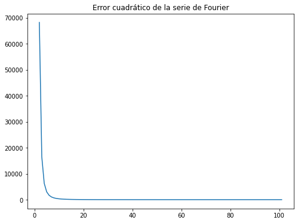

```python
N = 100
I = np.linspace(-tau,tau,num=1000)
error = np.zeros(N)
F = f(I)
for n in range(2,N+2):
    sum = 0
    for x in I:
        sum += (f(x)-Sf(x,f,n,tau))**2
    error[n-2] = sum

plt.figure(figsize=(8,6))
plt.plot(range(2,N+2),error)
plt.title("Error cuadrático de la serie de Fourier")
plt.show()
```